# Analysis Report

Cameron Lian

## Examining the Inflated Case Fatality Rate

The unexpected coronavirus disease 2019 (COVID-19) caught the world unprepared and suffered from extensive tolls of infection and death that many would considered inconcievable in the modern era since the Great Influenza of 1918. As of 31 December 2021, more than 287 million confirmed cases of COVID-19 has been reported to the World Health Organization (WHO), including 5.4 millions deaths (https://covid19.who.int/), while more than 52 million cases with more than 0.8 million deaths emerged in the United States alone (https://coronavirus.jhu.edu/data/).

Since its first outbreak in Wuhan, China in December of 2019, people spent extraordinary efforts to collect COVID-19 data for tracking its progression and impact, yet validation of the data has been riddled with challenges. COVID-19 infections are asymptomatic while most patients suffer from mild to moderate illness with respiratory and flu-like symptoms, which are usually not severe enough to cause critical conditions or even death. However, becuase of its prevalence across the world, it is compelling to attribute many patient deaths to COVID-19 for conveninence and funding-related issues.

The few reports align with the high median age of 70 years for COVID-19 deaths {Elezkurtaj, 2021 #614}, at which age a person’s physiological functions decline so much that is no longer sufficient to defend against the highly-infectious virus.

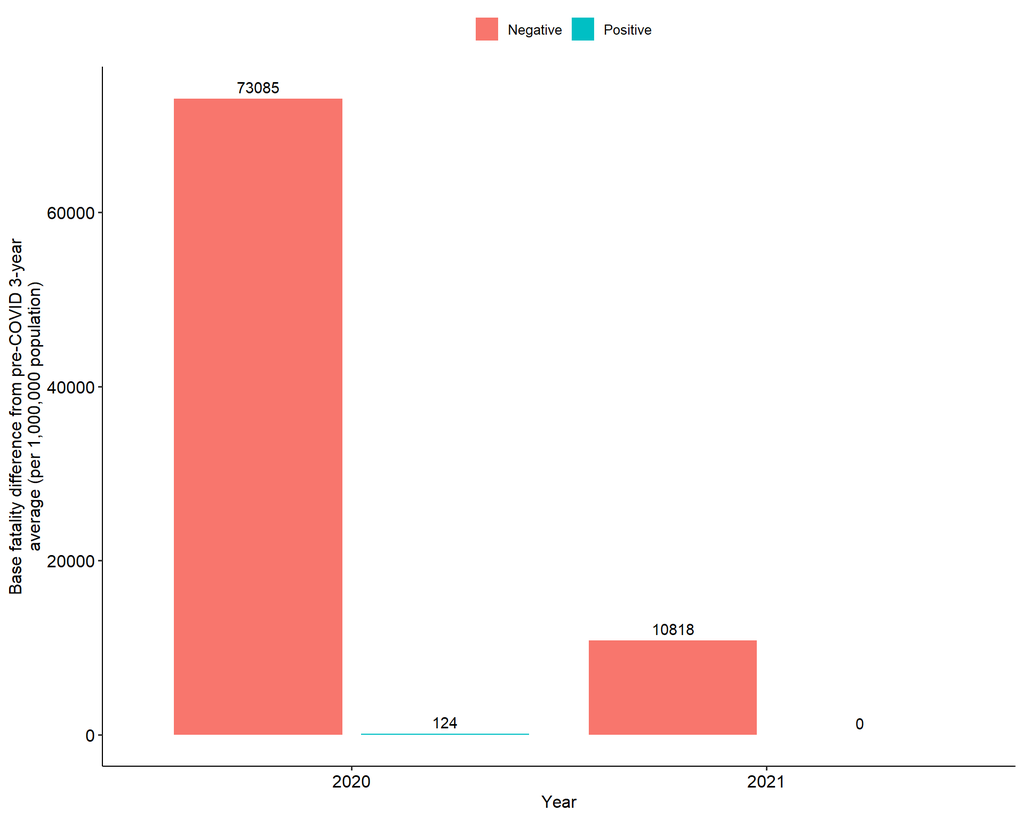

Figure. Difference in base fatality rate of COVID-19 era than pre-COVID-19 era. Base fatality rate refers to the fatality rate excluding those whose death was attributed to COVID-19.

```r
df_summary <- df_use %>%
  group_by(year) %>%
  summarise(
    n_fatality_diff_negative = sum(fatality_to_last_yrs < 0, na.rm = TRUE),
    n_fatality_diff_positive = sum(fatality_to_last_yrs > 0, na.rm = TRUE)
  ) %>%
  ungroup() %>%
  mutate(
    year = as.factor(year)
  )

df_long <- df_summary %>%
  pivot_longer(
    cols = starts_with("n_"),
    names_to = "variable",
    values_to = "value"
  ) %>%
  mutate(variable = ifelse(variable == "n_fatality_diff_negative", "Negative", "Positive"))

ggplot(data = df_long,
       mapping = aes(x = year,
                     y = value,
                     fill = variable)) +
  geom_col(position = position_dodge2(preserve = "single",
                                      padding = 0.1)) +
  geom_text(aes(y = value,
                label = value),
            position = position_dodge2(preserve = "single",
                                       width = 0.9, padding = 0.1),
            vjust = -0.5) +
  theme_pubr() +
  labs(
    fill = NULL,
    x = "Year",
    y = str_wrap("Base fatality difference from pre-COVID 3-year average (per 1,000,000 population)",
                 width = 50)
    )
```

## Understanding of policy trends

The policy data was acquired from the COVID Analysis and Mapping of Policy (COVID AMP) dataset {Katz, 2023 #332}.

```r
df_policy <- read_csv("data/data-files/raw_policy_data.csv")

policy_use <- df_policy %>%
  mutate(
    affected_local_code = as.character(affected_local_code),
    auth_local_code = as.character(auth_local_code)
    )
```

```r
df_party <- read_csv("data/data-files/Cook PVI (116th Congressional Districts) by County.csv")

party_updated <- df_party %>%
  mutate(
    party = ifelse(party == "R", "Republican", "Democratic")
  )
```

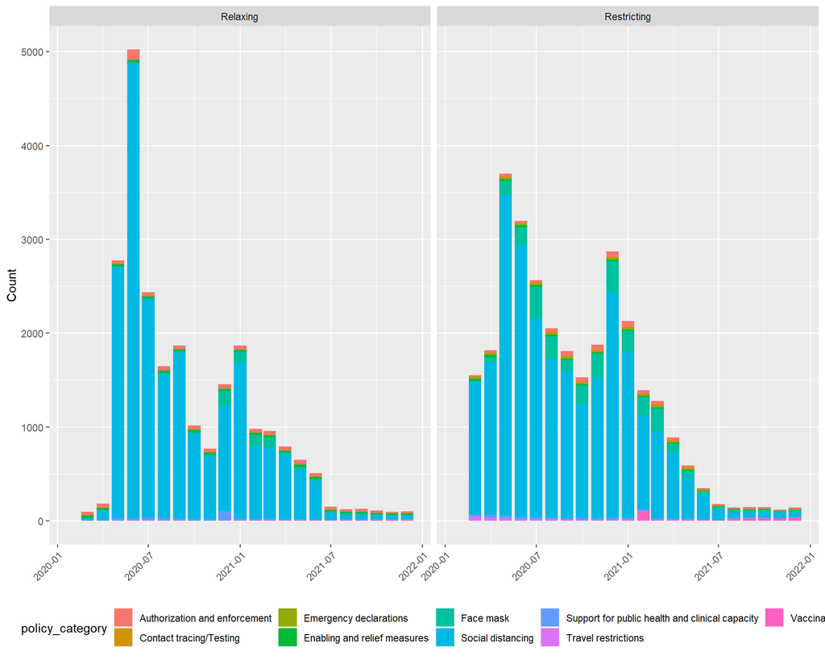

Figure. Policy distribution by category and month.

```r
policy_updated <- df_policy %>%
  mutate(
    issued_date = ymd(issued_date)
      )

policy_summary <- policy_updated %>%
  group_by(policy_year, policy_month, policy_category, policy_type) %>%
  summarise(
    count = n()
  ) %>%
  mutate(
    ymd = as.Date(paste(policy_year, policy_month, "01", sep = "-"),
                   format = "%Y-%m-%d")
  )

total_count <- policy_summary %>%
  group_by(ymd, policy_type) %>%
  summarise(
    total_count = sum(count)
  )

policy_summary_updated <- merge(policy_summary,
                                total_count,
                                by = c("ymd", "policy_type")) %>%
  mutate(
    percentage = count / total_count
  ) %>%
  filter(policy_type %in% c("Relaxing", "Restricting"),
         policy_year %in% c("2020", "2021"))

ggplot(data = policy_summary_updated,
       mapping = aes(x = ymd,
                     y = count,
                     fill = policy_category)) +
  geom_col() +
  # scale_y_log10() +
  # geom_text(aes(label = round(percentage, digits = 2)),
  #           size = 2, col = "white") +
  facet_grid(.~ policy_type) +
  labs(x = element_blank(),
       y = "Count") +
  theme(
    legend.position = "bottom",
    axis.text.x = element_text(angle = 45,
                               hjust = 1)
        )
```

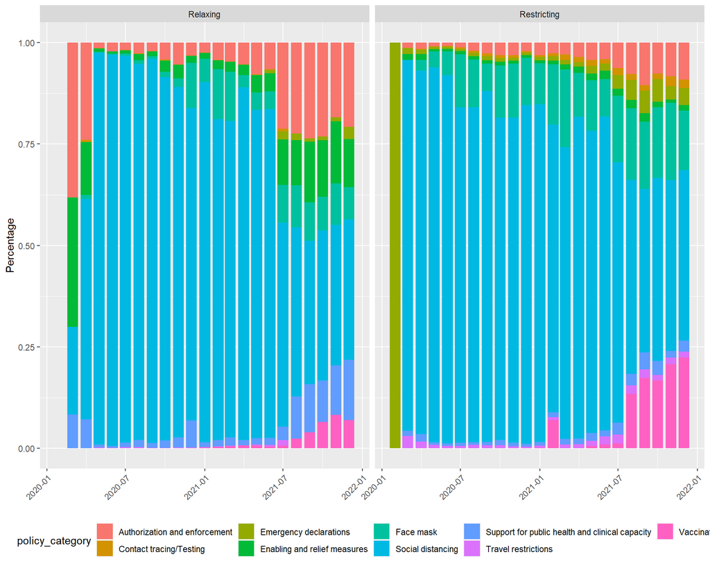

```r
ggplot(data = policy_summary_updated,
       mapping = aes(x = ymd,
                     y = percentage,
                     fill = policy_category)) +
  geom_col() +
  # geom_text(aes(label = round(percentage, digits = 2)),
  #           size = 2, col = "white") +
  facet_grid(.~ policy_type) +
  labs(x = element_blank(),
       y = "Percentage") +
  theme(
    legend.position = "bottom",
    axis.text.x = element_text(angle = 45,
                               hjust = 1)
  )
```

```r
policy_updated <- policy_use %>%
  filter(
    auth_level_gov == "Local",
    nchar(auth_local_code) == 5
  )

policy_updated <- merge(x = policy_updated,
                        y = party_updated,
                        by.x = "auth_local_code",
                        by.y = "county_fips")

policy_summary <- policy_updated %>%
  group_by(policy_year, policy_month, policy_category, policy_type, party) %>%
  summarise(count = n()) %>%
  mutate(
    ymd = as.Date(paste(policy_year, policy_month, "01", sep = "-"),
                   format = "%Y-%m-%d")
  )

total_count <- policy_summary %>%
  group_by(ymd, policy_type, party) %>%
  summarise(
    total_count = sum(count)
  )

policy_summary_updated <- merge(policy_summary,
                                total_count,
                                by = c("ymd", "policy_type", "party"))

policy_summary <- policy_summary_updated %>%
  mutate(
    percentage = count / total_count,
    count_normalized = as.vector(scale(count))
  ) %>%
  filter(policy_type %in% c("Relaxing", "Restricting"),
         policy_year %in% c("2020", "2021"))

# ggplot() +
#   geom_col(data = policy_summary,
#        mapping = aes(x = ymd,
#                      y = percentage,
#                      fill = policy_category)) +
#   geom_density(data = policy_summary,
#                mapping = aes(x = ymd,
#                              y = count_normalized,
#                              fill = policy_category),
#                alpha = 0.5) +
#
#   facet_grid(party ~ policy_type) +
#   labs(x = element_blank(),
#        y = "Count") +
#   theme(
#     legend.position = "bottom",
#     axis.text.x = element_text(angle = 45,
#                                hjust = 1)
#         )
```

```r
policy_summary <- df_policy %>%
  group_by(policy_category)

policy_filered <- df_policy %>%
  filter(
    policy_type %in% c("Relaxing", "Restricting"),
    policy_category %in% c("Authorization and enforcement",
                                "Face mask",
                                "Social distancing")
    )
```

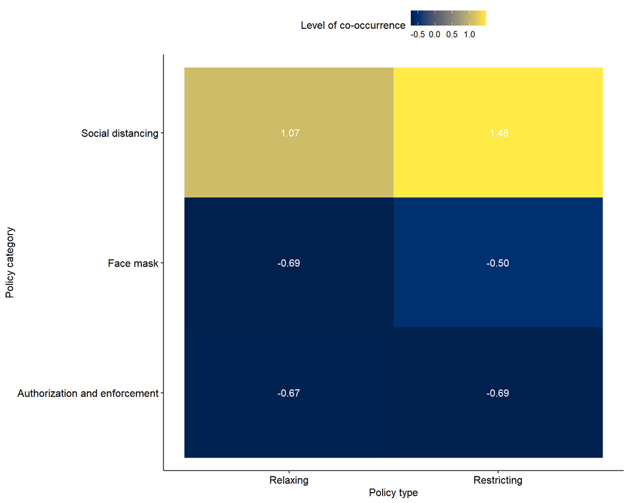

```r
policy_summary <- policy_filered %>%
  group_by(policy_type, policy_category) %>%
  summarise(count = n())

contingency_table <- xtabs(
  count ~
  policy_type + policy_category,
  data = policy_summary
)

ggplot(data = policy_summary,
       mapping = aes(x = policy_type,
                     y = policy_category,
                     fill = scale(count))) +
  geom_tile() +
  geom_text(aes(label = format(scale(count), digits = 2)),
            size = 4, col = "white") +
  labs(x = "Policy type",
       y = "Policy category",
       fill = "Level of co-occurrence") +
  scale_fill_viridis(option = "cividis") +
  theme_pubr()
```

But one limitation about this co-occurence plot is, since it counts the number of co-occurrence between each variable pair, it’s not comparable across pairs. For example, “Social distancing” has a much larger pool of policies than “Face mask”, hence, it’s standardized co-occurence count is expected to be larger than what is for “Face mask”.

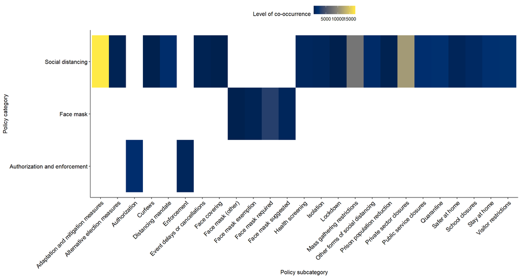

```r
policy_summary <- policy_filered %>%
  group_by(policy_category, policy_subcategory) %>%
  summarise(count = n())

ggplot(data = policy_summary,
       mapping = aes(x = policy_subcategory,
                     y = policy_category,
                     fill = count)) +
  geom_tile() +
  # geom_text(aes(label = format(scale(count), digits = 2)),
  #         size = 4, col = "white") +
  labs(x = "Policy subcategory",
       y = "Policy category",
       fill = "Level of co-occurrence") +
  scale_fill_viridis(option = "cividis") +
  theme_pubr() +
  theme(
    axis.text.x = element_text(angle = 45,
                               hjust = 1)
  )
```

[figure not shown]

```r
policy_summary <- policy_filered %>%
  group_by(policy_category, policy_target) %>%
  summarise(count = n())

ggplot(data = policy_summary,
       mapping = aes(x = policy_target,
                     y = policy_category,
                     fill = scale(count))) +
  geom_tile() +
  # geom_text(aes(label = format(scale(count), digits = 2)),
  #           size = 4, col = "white") +
  labs(x = "Policy type",
       y = "Policy category",
       fill = "Level of co-occurrence") +
  scale_fill_viridis(option = "cividis") +
  theme_pubr() +
  theme(
    axis.text.x = element_text(angle = 90,
                               hjust = 1,
                               size = 1)
  )
```